# Introduction to SPSS

## Independent-samples t test

**Question: Is average tenure different for female and male employees?**

To answer it, we test whether the sample means of tenure for men and women are statistically different, which an independent-samples t test does.

An independent-samples t test tells you whether there is a difference between the means of two groups on a particular variable. The dependent variable (**Test Variable**) must be continuous (interval or ratio level), and the independent variable (**Grouping Variable**) must be categorical (nominal or ordinal) with exactly two categories.

The hypotheses for our question are:

$$H_0: \mu_{Male} - \mu_{Female} = 0$$

The difference of the means is equal to zero.

$$H_1: \mu_{Male} - \mu_{Female} \neq 0$$

The difference of the means is not equal to zero.

where $\mu_{Male}$ and $\mu_{Female}$ are the population means for men and women.

**NoteIn SPSS: an independent-samples t test**

1. Click **Analyze > Compare Means and Proportions > Independent-Samples T Test**.
2. Move a quantitative variable into **Test Variable(s)**, such as **Tenure** (codebook ↑). This is the dependent variable.
3. Move a categorical variable into **Grouping Variable**, such as **Gender**. This is the independent variable.
4. Click **Define Groups** and fill in the codes for the two categories you want to compare. Female is 1 and male is 2 (codebook ↑), so put **1** in Group 1 and **2** in Group 2. Click **Continue**.
5. Check **Homogeneity of variance test**, so the output includes Levene’s test.
6. Click **Options** and check that the Confidence Interval Percentage is **95**. That means your alpha (what you compare your p-value to for statistical significance) is 0.05 (5%). Click **Continue**.
7. Click **OK**.

[figure not shown]

The Independent-Samples T Test dialog and its Options.

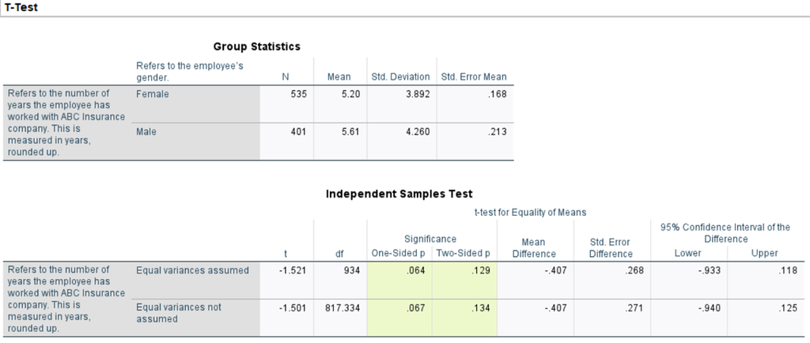

The Group Statistics and Independent Samples Test tables. This run left Homogeneity of variance test unchecked; with it checked, your table also has Levene’s F and Sig. columns.

### Reading the output

**Which row of the Independent Samples Test table do we read?** That depends on Levene’s test, which checks whether equal variances can be assumed. If Levene’s **Sig.** is greater than 0.05, use the first row, *Equal variances assumed*. If it is below 0.05, equal variances can’t be assumed, so use the second row, *Equal variances not assumed*.

**Is the difference significant?** In the row you chose, read the **Two-Sided p**. If it is smaller than 0.05, reject the null hypothesis. If it is greater than 0.05, fail to reject the null hypothesis: the difference between the two groups on this dependent variable is not statistically significant.

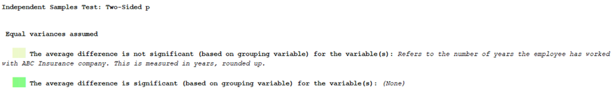

SPSS’s note on the highlighted cells.

**What is the Independent Samples Effect Sizes table?** It shows the effect size, which is also useful, for example, when estimating an appropriate sample size for a study. Find it in the **Point Estimate** column of the **Cohen’s d** row. As a rule of thumb, a d of about 0.2 is a small effect, about 0.5 a medium effect, and 0.8 or more a large effect.

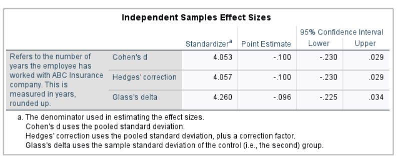

The Independent Samples Effect Sizes table.

**What values are standard to include in a report?**

- *N* (sample size)
- Mean
- *SD* (standard deviation)
- *t* (the t statistic)
- *df* (degrees of freedom). For an independent-samples t test with equal variances assumed, it’s the two group sizes added together, minus 2 (535 + 401 − 2 = 934). The *Equal variances not assumed* row uses an adjusted df.
- Two-sided *p* (the p-value for that t and df)

**Interpretation:** No. Women average 5.20 years of tenure (SD 3.89, n = 535) and men 5.61 years (SD 4.26, n = 401), but the difference isn’t statistically significant (t(934) = −1.521, two-sided p = .129), and the effect is negligible (Cohen’s d = −0.10). The conclusion is the same whichever row Levene’s test points to: the second row’s two-sided p is .134.

## One-sample t test

**Question: Is average tenure at ABC Insurance different from the U.S. figure of 4.1 years?**

A one-sample t test tells you whether a sample mean is statistically different from a population value. The test variable must be continuous (interval or ratio level).

According to the [Bureau of Labor Statistics](https://www.bls.gov/news.release/pdf/tenure.pdf), the *median* number of years that wage and salary workers had been with their current employer was 4.1 years in January 2026. We want to test whether the sample mean of Tenure is significantly different from 4.1 with a one-sample t test.

The null and alternative hypotheses are:

$$H_0: \mu_{Tenure} = 4.1$$

The mean Tenure is equal to 4.1.

$$H_1: \mu_{Tenure} \neq 4.1$$

The mean Tenure is not equal to 4.1.

where $\mu_{Tenure}$ is the mean tenure.

**NoteIn SPSS: a one-sample t test**

1. Click **Analyze > Compare Means and Proportions > One-Sample T Test**.
2. Move your continuous test variable, such as **Tenure** (codebook ↑), into the **Test Variable(s)** box.
3. Type your target number, **4.1**, into the **Test Value** box.
4. Click **OK** to run the test.

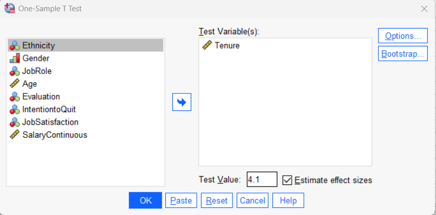

Tenure tested against 4.1.

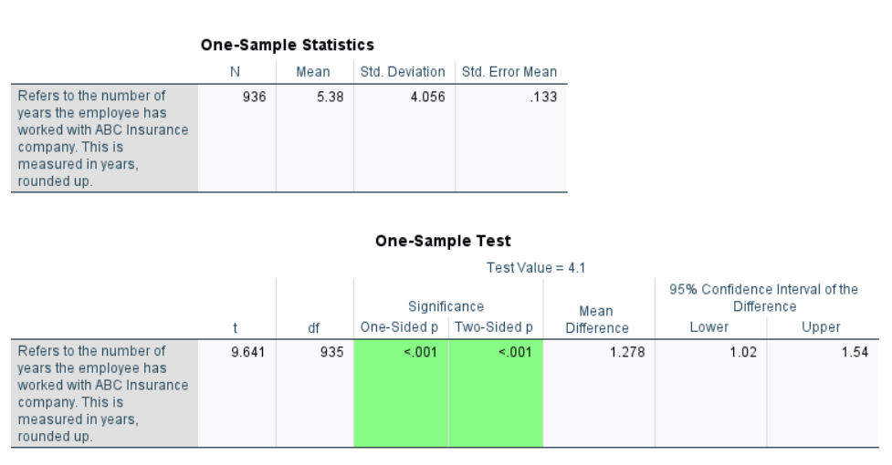

The One-Sample Statistics and One-Sample Test tables.

**Interpretation:** Yes. Mean tenure at ABC Insurance is 5.38 years, which is significantly different from 4.1 years (t(935) = 9.641, p < .001), so we reject the null hypothesis. Employees here have been with the company about 1.28 years longer than the U.S. figure (95% CI [1.02, 1.54]).